# SZ R Package Notes

Sara(Yuhua) Zong

2022-12-06

# 1 Writing an R package:

## 1.1 Tools–R packages to create R packages

1. **`devtools`** is a collection of R package developmental tools
   - For example `create("project")` creates a project folder for your R package
2. **`usethis`** creates things for package management
   - For example `use_r("file_name")` creates an *.R* file
3. **`roxygen`** generates documentations

More on how to use these packages below… …

## 1.2 HOW to Create an R Package:

1. Navigate to the desired project location with `setwd()` in RStudio
2. Use `devtools::create("<project_name>")` to create a new R project. It will create the following files inside the project folder:
   - an *R folder*
   - *DESCRIPTION*
   - *NAMESPACE*
   - *.Rproj*
     - If existing project doesn’t have an *.Rproj* file, create one with `devtools::use_rstudio("<path/to/package>")`. *.Rproj* file contains project option information
   - *.gitignore*
   - *.Rbuildignore*
3. Work on the *DESCRIPTION* file, reference for details [here](https://bookdown.dongzhuoer.com/hadley/r-pkgs/description.html):
   - Modify **Title** and **Description** accordingly (**Note:** values span multiple lines in the *DESCRIPTION* file needs four spaces indent)
   - Modify **Authors@R** with `person("first_name", "last_name", email = ..., role = c("aut", "cre"))`
   - Use `devtools::use_package("package_name")` to add package dependency to **Import:**
   - Use `devtools::use_package("package_name", "Suggests")` to add package to **Suggests:**
   - If any of your functions provides the option to use the suggested package, check if the package is installed with `requireNamespace("package_name", quietly=TRUE)`
   - Use `devtools::use_build_ignore("note")` to modify the *.Rbuildignore* file
4. Add functions to *.R* files in the *R folder*:
   - `use_this::use_r("file_name")` to creat a blank *.R* file in the R folder
   - Tips and tricks for functions:
     - Variable names should be nouns and function names should be verbs
     - Use two spaces when indent your code
     - Comments should explain the why, not the what
     - Use `#------` to break up your code into easily readable chunks
   - Add function documentation:
     - Title in the format of `#' @title <fxn title>`
     - Description in the format of `#' @description <fxn description>`
     - Parameter(s) in the format of `#' @param <name> <description>`
     - Output in the format of `#' @return <fxn outupt>`
     - Example of how function is used in the format of `#' @example(s) <example>` (**Note:** example will need to pass check if it’s added to documentation)
     - Don’t forget to `#' @export`

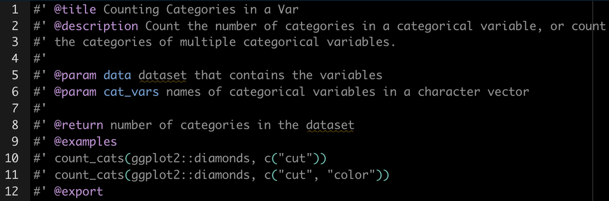

   - `devtools::document()` creates the nicely formatted function documentations, which are in the Rd files, and they could be converted to HTML or [PDF](https://stackoverflow.com/questions/3779864/how-do-i-convert-rd-files-to-pdf-for-a-package-that-i-am-creating-in-r)
   - use template .R file or template documentation (`#'@template file_name`), or documentation referencing (`#'@inheritParams function_name`) for consistent function documentation
5. To add the **`magrittr`** pipe, use `usethis::use_pipe()`
6. Add files/directories to *.Rbuildignore* if they should not be distributed
   - `usethis::use_build_ignore("<file/directory_name>")`
7. Build package with `devtools::build()`
8. Check package for errors, warnings, and notes with `devtools::check()`
9. Use GitHub Actions to check codes add to the repo:
   - `usethis::use_github_action_check_standard()` for standard check
   - `usethis::use_github_action_check_release()` for quick check
   - Either function creates a `.github` folder, a `workflows` folder with a `R-CMD-check.yaml` file inside, and a `R-CMD-check` badge will be added to the `README.md`

## 1.3 How to Consistently Document R Functions

### 1.3.1 Create a Template .R File

**Reference:** [stackoverflow post](https://stackoverflow.com/questions/35158708/how-to-set-default-template-for-new-r-files-in-rstudio)

1. First create a *template folder* in the *.config folder*
   - `cd ~/.config/rstudio`
   - `mkdir template`
2. Then create a *default.R* file
   - `cd template`
   - `touch default.R`
   - `open default.R` and add to the *default.R* file

### 1.3.2 Create a Template Doc File

1. First create a *man-roxygen folder* in the project folder
2. Add the folder to the *.Rbuildignore*
   - `usethis::use_build_ignore("man-roxygen")`
3. Create template documentation .R file
   - For example, “#’@param var_x blah blah blah” to var_x.R

## 1.4 Understand the WHYs

**Reference:** first edition of [R Packages](https://bookdown.dongzhuoer.com/hadley/r-pkgs/index.html), second edition is work in progress.

1. What is the difference between `devtools` and `usethis`? [Hmmm](https://github.com/r-lib/devtools/issues/1985)
2. Five states of a package:
   - **source:** local development version of a package
   - **bundled:** package that’s compressed to a single file, it’s created by calling `devtools::build()`. Files added to *“.Rbuildignore”* are not included in the bundle. Package bundle is generated for code distribution!?
   - **binary:** similar to package bundle that it’s compressed to a single file, but its internal structure is rearranged from a source package. Binary package is generated for distribution that `install.packages()` download and install binary packages built by CRAN.
   - **installed:** is a binary package decompressed into a package library
   - **in memory:** load installed package to memory
3. What is a library? A directory containing installed packages. Library varies based on the version of R. When upgrade R, all packages need to be re-install not because they disappear, but only that R cannot find them.
4. What is the difference between `devtools::load_all()` and “Build & Reload”?
   - `devtools::load_all()` sources all files in *R/*
5. What is the difference between `library()` and `require()`? When a package is not found, `library()` throws an error but `require()` prints a message and returns `FALSE`.
6. When a package is built, code in *R/* is executed and the results are saved. They are made available to use when package is loaded with `library()` or `require()`.
7. `DESCRIPTION` lists the packages your package needs. Specify required packages in `DESCRIPTION$Imports` and they will be installed when your package is installed. List suggested packages under `DESCRIPTION$Suggests`, those are the packages can be used but not required (Not sure if I understand the difference since I would have `suggested_package::fxn` even for functions from the suggested packages in my codes, right?! Okay, I think it means if you have an alternative execution to `suggested_package::fxn`, you can let your package users know that they can use the `suggested_package::fxn` with your fxns). **For examples:**

```r
# Here you are telling your package users that they need to install the suggested_pkg.
# Why not put the package under Imports?? If the suggested package is only required
# by one less-frequently-used function among many of your other functions, maybe it's
# a good idea to let the users install the suggested package when they need it.
# When developing package locally, you don't really need to use Suggests.
fxn <- function(x, y) {
  if (!requireNamespace("suggested_pkg", quietly = TRUE)) {
    stop("Suggested_pkg needed for this function. Please install it.", call. = FALSE)
  }
}

# Here you have an alternative execution, but user could also choose to use the
# suggested package
fxn <- function(x, y) {
  if (!requireNamespace("suggested_pkg", quietly = TRUE)) {
    suggested_pkg::fxn()
  } else {
    fxn()
  }
}
```

8. Version of the required packages under **Imports:** can be specified like this:

```r
Imports:
  pakcage_x (>= version_of_the_pacakge_you_are_using_for_development)
```